# Risk Factor Analysis

## Outcome Variable

**Outcome Variable:** wasted

## Predictor Variables

**Intervention Variable:** mbmi

**Adjustment Set:**

unadjusted

## Stratifying Variables

The analysis was stratified on these variable(s):

- agecat
- studyid
- country

## Data Summary

| agecat | studyid | country | mbmi | wasted | n_cell | n |
| --- | --- | --- | --- | --- | --- | --- |
| Birth | ki0047075b-MAL-ED | BANGLADESH | Normal weight | 0 | 154 | 209 |
| Birth | ki0047075b-MAL-ED | BANGLADESH | Normal weight | 1 | 29 | 209 |
| Birth | ki0047075b-MAL-ED | BANGLADESH | Underweight | 0 | 20 | 209 |
| Birth | ki0047075b-MAL-ED | BANGLADESH | Underweight | 1 | 6 | 209 |
| Birth | ki0047075b-MAL-ED | BRAZIL | Normal weight | 0 | 55 | 61 |
| Birth | ki0047075b-MAL-ED | BRAZIL | Normal weight | 1 | 1 | 61 |
| Birth | ki0047075b-MAL-ED | BRAZIL | Underweight | 0 | 4 | 61 |
| Birth | ki0047075b-MAL-ED | BRAZIL | Underweight | 1 | 1 | 61 |
| Birth | ki0047075b-MAL-ED | INDIA | Normal weight | 0 | 29 | 41 |
| Birth | ki0047075b-MAL-ED | INDIA | Normal weight | 1 | 4 | 41 |
| Birth | ki0047075b-MAL-ED | INDIA | Underweight | 0 | 7 | 41 |
| Birth | ki0047075b-MAL-ED | INDIA | Underweight | 1 | 1 | 41 |
| Birth | ki0047075b-MAL-ED | NEPAL | Normal weight | 0 | 24 | 26 |
| Birth | ki0047075b-MAL-ED | NEPAL | Normal weight | 1 | 2 | 26 |
| Birth | ki0047075b-MAL-ED | NEPAL | Underweight | 0 | 0 | 26 |
| Birth | ki0047075b-MAL-ED | NEPAL | Underweight | 1 | 0 | 26 |
| Birth | ki0047075b-MAL-ED | PERU | Normal weight | 0 | 211 | 221 |
| Birth | ki0047075b-MAL-ED | PERU | Normal weight | 1 | 5 | 221 |
| Birth | ki0047075b-MAL-ED | PERU | Underweight | 0 | 5 | 221 |
| Birth | ki0047075b-MAL-ED | PERU | Underweight | 1 | 0 | 221 |
| Birth | ki0047075b-MAL-ED | SOUTH AFRICA | Normal weight | 0 | 87 | 100 |
| Birth | ki0047075b-MAL-ED | SOUTH AFRICA | Normal weight | 1 | 10 | 100 |
| Birth | ki0047075b-MAL-ED | SOUTH AFRICA | Underweight | 0 | 3 | 100 |
| Birth | ki0047075b-MAL-ED | SOUTH AFRICA | Underweight | 1 | 0 | 100 |
| Birth | ki0047075b-MAL-ED | TANZANIA, UNITED REPUBLIC OF | Normal weight | 0 | 106 | 113 |
| Birth | ki0047075b-MAL-ED | TANZANIA, UNITED REPUBLIC OF | Normal weight | 1 | 1 | 113 |
| Birth | ki0047075b-MAL-ED | TANZANIA, UNITED REPUBLIC OF | Underweight | 0 | 6 | 113 |
| Birth | ki0047075b-MAL-ED | TANZANIA, UNITED REPUBLIC OF | Underweight | 1 | 0 | 113 |
| Birth | ki1000304b-SAS-CompFeed | INDIA | Normal weight | 0 | 667 | 992 |
| Birth | ki1000304b-SAS-CompFeed | INDIA | Normal weight | 1 | 68 | 992 |

[output cut: 150 more lines]

The following strata were considered:

- agecat: 24 months, studyid: ki0047075b-MAL-ED, country: BANGLADESH
- agecat: 24 months, studyid: ki0047075b-MAL-ED, country: BRAZIL
- agecat: 24 months, studyid: ki0047075b-MAL-ED, country: INDIA
- agecat: 24 months, studyid: ki0047075b-MAL-ED, country: NEPAL
- agecat: 24 months, studyid: ki0047075b-MAL-ED, country: PERU
- agecat: 24 months, studyid: ki0047075b-MAL-ED, country: SOUTH AFRICA
- agecat: 24 months, studyid: ki0047075b-MAL-ED, country: TANZANIA, UNITED REPUBLIC OF
- agecat: 24 months, studyid: ki1017093-NIH-Birth, country: BANGLADESH
- agecat: 24 months, studyid: ki1017093b-PROVIDE, country: BANGLADESH
- agecat: 24 months, studyid: ki1017093c-NIH-Crypto, country: BANGLADESH
- agecat: 24 months, studyid: ki1066203-TanzaniaChild2, country: TANZANIA, UNITED REPUBLIC OF
- agecat: 24 months, studyid: ki1119695-PROBIT, country: BELARUS
- agecat: 24 months, studyid: ki1126311-ZVITAMBO, country: ZIMBABWE
- agecat: 24 months, studyid: ki1148112-LCNI-5, country: MALAWI
- agecat: 24 months, studyid: kiGH5241-JiVitA-3, country: BANGLADESH
- agecat: 6 months, studyid: ki0047075b-MAL-ED, country: BANGLADESH
- agecat: 6 months, studyid: ki0047075b-MAL-ED, country: BRAZIL
- agecat: 6 months, studyid: ki0047075b-MAL-ED, country: INDIA
- agecat: 6 months, studyid: ki0047075b-MAL-ED, country: NEPAL
- agecat: 6 months, studyid: ki0047075b-MAL-ED, country: PERU
- agecat: 6 months, studyid: ki0047075b-MAL-ED, country: SOUTH AFRICA
- agecat: 6 months, studyid: ki0047075b-MAL-ED, country: TANZANIA, UNITED REPUBLIC OF
- agecat: 6 months, studyid: ki1000304b-SAS-CompFeed, country: INDIA
- agecat: 6 months, studyid: ki1017093-NIH-Birth, country: BANGLADESH
- agecat: 6 months, studyid: ki1017093b-PROVIDE, country: BANGLADESH
- agecat: 6 months, studyid: ki1017093c-NIH-Crypto, country: BANGLADESH
- agecat: 6 months, studyid: ki1066203-TanzaniaChild2, country: TANZANIA, UNITED REPUBLIC OF
- agecat: 6 months, studyid: ki1119695-PROBIT, country: BELARUS
- agecat: 6 months, studyid: ki1126311-ZVITAMBO, country: ZIMBABWE
- agecat: 6 months, studyid: ki1148112-LCNI-5, country: MALAWI
- agecat: 6 months, studyid: kiGH5241-JiVitA-3, country: BANGLADESH
- agecat: Birth, studyid: ki0047075b-MAL-ED, country: BANGLADESH
- agecat: Birth, studyid: ki0047075b-MAL-ED, country: BRAZIL
- agecat: Birth, studyid: ki0047075b-MAL-ED, country: INDIA
- agecat: Birth, studyid: ki0047075b-MAL-ED, country: NEPAL
- agecat: Birth, studyid: ki0047075b-MAL-ED, country: PERU
- agecat: Birth, studyid: ki0047075b-MAL-ED, country: SOUTH AFRICA
- agecat: Birth, studyid: ki0047075b-MAL-ED, country: TANZANIA, UNITED REPUBLIC OF
- agecat: Birth, studyid: ki1000304b-SAS-CompFeed, country: INDIA
- agecat: Birth, studyid: ki1017093-NIH-Birth, country: BANGLADESH
- agecat: Birth, studyid: ki1017093b-PROVIDE, country: BANGLADESH
- agecat: Birth, studyid: ki1017093c-NIH-Crypto, country: BANGLADESH
- agecat: Birth, studyid: ki1119695-PROBIT, country: BELARUS
- agecat: Birth, studyid: ki1126311-ZVITAMBO, country: ZIMBABWE
- agecat: Birth, studyid: kiGH5241-JiVitA-3, country: BANGLADESH

### Dropped Strata

Some strata were dropped due to rare outcomes:

- agecat: Birth, studyid: ki0047075b-MAL-ED, country: BRAZIL
- agecat: Birth, studyid: ki0047075b-MAL-ED, country: INDIA
- agecat: Birth, studyid: ki0047075b-MAL-ED, country: NEPAL
- agecat: Birth, studyid: ki0047075b-MAL-ED, country: PERU
- agecat: Birth, studyid: ki0047075b-MAL-ED, country: SOUTH AFRICA
- agecat: Birth, studyid: ki0047075b-MAL-ED, country: TANZANIA, UNITED REPUBLIC OF
- agecat: 6 months, studyid: ki0047075b-MAL-ED, country: BANGLADESH
- agecat: 6 months, studyid: ki0047075b-MAL-ED, country: BRAZIL
- agecat: 6 months, studyid: ki0047075b-MAL-ED, country: NEPAL
- agecat: 6 months, studyid: ki0047075b-MAL-ED, country: PERU
- agecat: 6 months, studyid: ki0047075b-MAL-ED, country: SOUTH AFRICA
- agecat: 6 months, studyid: ki0047075b-MAL-ED, country: TANZANIA, UNITED REPUBLIC OF
- agecat: 6 months, studyid: ki1066203-TanzaniaChild2, country: TANZANIA, UNITED REPUBLIC OF
- agecat: 6 months, studyid: ki1148112-LCNI-5, country: MALAWI
- agecat: 24 months, studyid: ki0047075b-MAL-ED, country: BRAZIL
- agecat: 24 months, studyid: ki0047075b-MAL-ED, country: NEPAL
- agecat: 24 months, studyid: ki0047075b-MAL-ED, country: PERU
- agecat: 24 months, studyid: ki0047075b-MAL-ED, country: SOUTH AFRICA
- agecat: 24 months, studyid: ki0047075b-MAL-ED, country: TANZANIA, UNITED REPUBLIC OF
- agecat: 24 months, studyid: ki1017093c-NIH-Crypto, country: BANGLADESH
- agecat: 24 months, studyid: ki1066203-TanzaniaChild2, country: TANZANIA, UNITED REPUBLIC OF

## Methods Detail

We’re interested in the causal parameters $E[Y_a]$ for all values of $a \in \mathcal{A}$. These parameters represent the mean outcome if, possibly contrary to fact, we intervened to set all units to have $A=a$. Under the randomization and positivity assumptions, these are identified by the statistical parameters $\psi_a=E_W[E_{Y|A,W}(Y|A=a,W)]$. In addition, we’re interested in the mean of $Y$, $E[Y]$ under no intervention (the observed mean). We will estimate these parameters by using SuperLearner to fit the relevant likelihood factors – $E_{Y|A,W}(Y|A=a,W)$ and $p(A=a|W)$, and then updating our likelihood fit using a joint TMLE.

For unadjusted analyses ($W=\{\}$), initial likelihoods were estimated using Lrnr_glm to estimate the simple $E(Y|A)$ and Lrnr_mean to estimate $p(A)$. For adjusted analyses, a small library containing Lrnr_glmnet, Lrnr_xgboost, and Lrnr_mean was used.

Having estimated these parameters, we will then use the delta method to estimate relative risks and attributable risks relative to a prespecified baseline level of $A$.

# Results Detail

## Results Plots

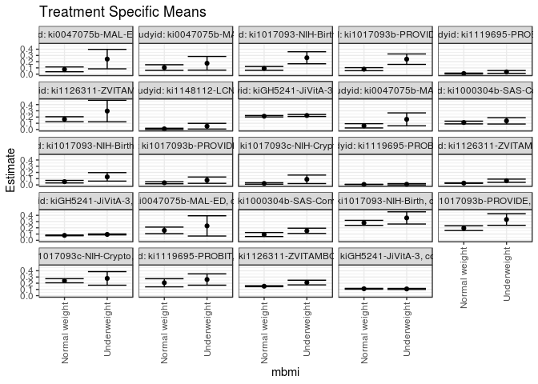

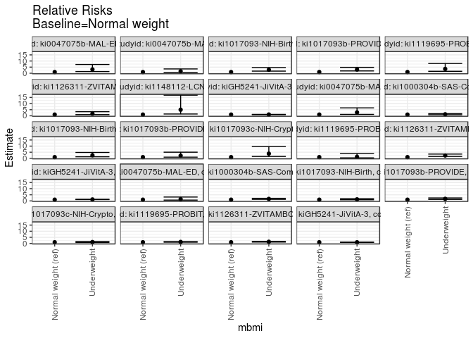

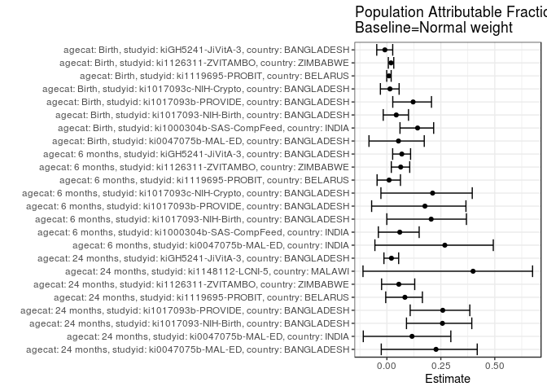

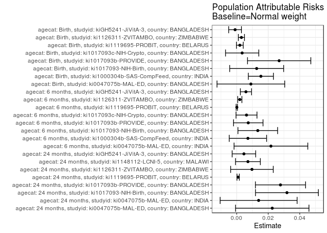

## Results Table

### Parameter: TSM

| agecat | studyid | country | intervention_level | baseline_level | estimate | ci_lower | ci_upper |
| --- | --- | --- | --- | --- | --- | --- | --- |
| Birth | ki0047075b-MAL-ED | BANGLADESH | Normal weight | NA | 0.1584699 | 0.1054338 | 0.2115061 |
| Birth | ki0047075b-MAL-ED | BANGLADESH | Underweight | NA | 0.2307692 | 0.0684312 | 0.3931072 |
| Birth | ki1000304b-SAS-CompFeed | INDIA | Normal weight | NA | 0.0925170 | 0.0601932 | 0.1248408 |
| Birth | ki1000304b-SAS-CompFeed | INDIA | Underweight | NA | 0.1517510 | 0.1093176 | 0.1941843 |
| Birth | ki1017093-NIH-Birth | BANGLADESH | Normal weight | NA | 0.2795031 | 0.2394476 | 0.3195586 |
| Birth | ki1017093-NIH-Birth | BANGLADESH | Underweight | NA | 0.3586957 | 0.2606051 | 0.4567862 |
| Birth | ki1017093b-PROVIDE | BANGLADESH | Normal weight | NA | 0.1946472 | 0.1563321 | 0.2329624 |
| Birth | ki1017093b-PROVIDE | BANGLADESH | Underweight | NA | 0.3333333 | 0.2403831 | 0.4262836 |
| Birth | ki1017093c-NIH-Crypto | BANGLADESH | Normal weight | NA | 0.2394366 | 0.2063258 | 0.2725474 |
| Birth | ki1017093c-NIH-Crypto | BANGLADESH | Underweight | NA | 0.2769231 | 0.1680622 | 0.3857840 |
| Birth | ki1119695-PROBIT | BELARUS | Normal weight | NA | 0.2067260 | 0.1415231 | 0.2719289 |
| Birth | ki1119695-PROBIT | BELARUS | Underweight | NA | 0.2591171 | 0.1683674 | 0.3498668 |
| Birth | ki1126311-ZVITAMBO | ZIMBABWE | Normal weight | NA | 0.1513879 | 0.1438007 | 0.1589751 |
| Birth | ki1126311-ZVITAMBO | ZIMBABWE | Underweight | NA | 0.2105263 | 0.1731056 | 0.2479470 |
| Birth | kiGH5241-JiVitA-3 | BANGLADESH | Normal weight | NA | 0.1107554 | 0.1040213 | 0.1174896 |
| Birth | kiGH5241-JiVitA-3 | BANGLADESH | Underweight | NA | 0.1081274 | 0.1001953 | 0.1160595 |
| 6 months | ki0047075b-MAL-ED | INDIA | Normal weight | NA | 0.0591398 | 0.0251679 | 0.0931117 |
| 6 months | ki0047075b-MAL-ED | INDIA | Underweight | NA | 0.1632653 | 0.0595562 | 0.2669744 |
| 6 months | ki1000304b-SAS-CompFeed | INDIA | Normal weight | NA | 0.1119734 | 0.0902067 | 0.1337401 |
| 6 months | ki1000304b-SAS-CompFeed | INDIA | Underweight | NA | 0.1388889 | 0.0879530 | 0.1898248 |
| 6 months | ki1017093-NIH-Birth | BANGLADESH | Normal weight | NA | 0.0518018 | 0.0311678 | 0.0724358 |
| 6 months | ki1017093-NIH-Birth | BANGLADESH | Underweight | NA | 0.1290323 | 0.0608358 | 0.1972287 |
| 6 months | ki1017093b-PROVIDE | BANGLADESH | Normal weight | NA | 0.0342052 | 0.0182126 | 0.0501979 |
| 6 months | ki1017093b-PROVIDE | BANGLADESH | Underweight | NA | 0.0761905 | 0.0254031 | 0.1269779 |
| 6 months | ki1017093c-NIH-Crypto | BANGLADESH | Normal weight | NA | 0.0231481 | 0.0115621 | 0.0347342 |
| 6 months | ki1017093c-NIH-Crypto | BANGLADESH | Underweight | NA | 0.0895522 | 0.0211327 | 0.1579718 |
| 6 months | ki1119695-PROBIT | BELARUS | Normal weight | NA | 0.0078281 | 0.0057317 | 0.0099246 |
| 6 months | ki1119695-PROBIT | BELARUS | Underweight | NA | 0.0099010 | -0.0006297 | 0.0204317 |
| 6 months | ki1126311-ZVITAMBO | ZIMBABWE | Normal weight | NA | 0.0287749 | 0.0248247 | 0.0327251 |
| 6 months | ki1126311-ZVITAMBO | ZIMBABWE | Underweight | NA | 0.0672043 | 0.0417595 | 0.0926491 |
| 6 months | kiGH5241-JiVitA-3 | BANGLADESH | Normal weight | NA | 0.0787149 | 0.0730021 | 0.0844278 |
| 6 months | kiGH5241-JiVitA-3 | BANGLADESH | Underweight | NA | 0.0939347 | 0.0862175 | 0.1016518 |
| 24 months | ki0047075b-MAL-ED | BANGLADESH | Normal weight | NA | 0.0765027 | 0.0379011 | 0.1151044 |
| 24 months | ki0047075b-MAL-ED | BANGLADESH | Underweight | NA | 0.2413793 | 0.0852666 | 0.3974920 |
| 24 months | ki0047075b-MAL-ED | INDIA | Normal weight | NA | 0.1055556 | 0.0605680 | 0.1505431 |
| 24 months | ki0047075b-MAL-ED | INDIA | Underweight | NA | 0.1739130 | 0.0641361 | 0.2836900 |
| 24 months | ki1017093-NIH-Birth | BANGLADESH | Normal weight | NA | 0.0919540 | 0.0615588 | 0.1223493 |
| 24 months | ki1017093-NIH-Birth | BANGLADESH | Underweight | NA | 0.2625000 | 0.1659712 | 0.3590288 |
| 24 months | ki1017093b-PROVIDE | BANGLADESH | Normal weight | NA | 0.0794979 | 0.0552262 | 0.1037696 |
| 24 months | ki1017093b-PROVIDE | BANGLADESH | Underweight | NA | 0.2400000 | 0.1562207 | 0.3237793 |
| 24 months | ki1119695-PROBIT | BELARUS | Normal weight | NA | 0.0099974 | 0.0031354 | 0.0168593 |
| 24 months | ki1119695-PROBIT | BELARUS | Underweight | NA | 0.0354610 | 0.0131851 | 0.0577369 |
| 24 months | ki1126311-ZVITAMBO | ZIMBABWE | Normal weight | NA | 0.1651917 | 0.1256068 | 0.2047767 |
| 24 months | ki1126311-ZVITAMBO | ZIMBABWE | Underweight | NA | 0.2962963 | 0.1238244 | 0.4687682 |
| 24 months | ki1148112-LCNI-5 | MALAWI | Normal weight | NA | 0.0107066 | 0.0013641 | 0.0200492 |
| 24 months | ki1148112-LCNI-5 | MALAWI | Underweight | NA | 0.0531915 | 0.0077844 | 0.0985986 |
| 24 months | kiGH5241-JiVitA-3 | BANGLADESH | Normal weight | NA | 0.2133915 | 0.2016760 | 0.2251070 |
| 24 months | kiGH5241-JiVitA-3 | BANGLADESH | Underweight | NA | 0.2252881 | 0.2089836 | 0.2415925 |

### Parameter: E(Y)

| agecat | studyid | country | intervention_level | baseline_level | estimate | ci_lower | ci_upper |
| --- | --- | --- | --- | --- | --- | --- | --- |
| Birth | ki0047075b-MAL-ED | BANGLADESH | NA | NA | 0.1674641 | 0.1167208 | 0.2182074 |
| Birth | ki1000304b-SAS-CompFeed | INDIA | NA | NA | 0.1078629 | 0.0749278 | 0.1407980 |
| Birth | ki1017093-NIH-Birth | BANGLADESH | NA | NA | 0.2921739 | 0.2549711 | 0.3293768 |
| Birth | ki1017093b-PROVIDE | BANGLADESH | NA | NA | 0.2215686 | 0.1854897 | 0.2576475 |
| Birth | ki1017093c-NIH-Crypto | BANGLADESH | NA | NA | 0.2428977 | 0.2111977 | 0.2745977 |
| Birth | ki1119695-PROBIT | BELARUS | NA | NA | 0.2087237 | 0.1432464 | 0.2742009 |
| Birth | ki1126311-ZVITAMBO | ZIMBABWE | NA | NA | 0.1543743 | 0.1469218 | 0.1618269 |
| Birth | kiGH5241-JiVitA-3 | BANGLADESH | NA | NA | 0.1097296 | 0.1045905 | 0.1148686 |
| 6 months | ki0047075b-MAL-ED | INDIA | NA | NA | 0.0808511 | 0.0459229 | 0.1157792 |
| 6 months | ki1000304b-SAS-CompFeed | INDIA | NA | NA | 0.1190865 | 0.0945854 | 0.1435876 |
| 6 months | ki1017093-NIH-Birth | BANGLADESH | NA | NA | 0.0651769 | 0.0442802 | 0.0860736 |
| 6 months | ki1017093b-PROVIDE | BANGLADESH | NA | NA | 0.0415282 | 0.0255778 | 0.0574787 |
| 6 months | ki1017093c-NIH-Crypto | BANGLADESH | NA | NA | 0.0293706 | 0.0169860 | 0.0417552 |
| 6 months | ki1119695-PROBIT | BELARUS | NA | NA | 0.0079085 | 0.0059160 | 0.0099010 |
| 6 months | ki1126311-ZVITAMBO | ZIMBABWE | NA | NA | 0.0307459 | 0.0267728 | 0.0347190 |
| 6 months | kiGH5241-JiVitA-3 | BANGLADESH | NA | NA | 0.0845634 | 0.0797479 | 0.0893790 |
| 24 months | ki0047075b-MAL-ED | BANGLADESH | NA | NA | 0.0990566 | 0.0587480 | 0.1393652 |
| 24 months | ki0047075b-MAL-ED | INDIA | NA | NA | 0.1194690 | 0.0770894 | 0.1618486 |
| 24 months | ki1017093-NIH-Birth | BANGLADESH | NA | NA | 0.1238318 | 0.0925894 | 0.1550741 |
| 24 months | ki1017093b-PROVIDE | BANGLADESH | NA | NA | 0.1072664 | 0.0820169 | 0.1325160 |
| 24 months | ki1119695-PROBIT | BELARUS | NA | NA | 0.0109082 | 0.0040825 | 0.0177338 |
| 24 months | ki1126311-ZVITAMBO | ZIMBABWE | NA | NA | 0.1748634 | 0.1358949 | 0.2138319 |
| 24 months | ki1148112-LCNI-5 | MALAWI | NA | NA | 0.0178253 | 0.0068664 | 0.0287842 |
| 24 months | kiGH5241-JiVitA-3 | BANGLADESH | NA | NA | 0.2179697 | 0.2080911 | 0.2278482 |

### Parameter: RR

| agecat | studyid | country | intervention_level | baseline_level | estimate | ci_lower | ci_upper |
| --- | --- | --- | --- | --- | --- | --- | --- |
| Birth | ki0047075b-MAL-ED | BANGLADESH | Normal weight | Normal weight | 1.0000000 | 1.0000000 | 1.000000 |
| Birth | ki0047075b-MAL-ED | BANGLADESH | Underweight | Normal weight | 1.4562334 | 0.6682012 | 3.173619 |
| Birth | ki1000304b-SAS-CompFeed | INDIA | Normal weight | Normal weight | 1.0000000 | 1.0000000 | 1.000000 |
| Birth | ki1000304b-SAS-CompFeed | INDIA | Underweight | Normal weight | 1.6402495 | 1.2799564 | 2.101961 |
| Birth | ki1017093-NIH-Birth | BANGLADESH | Normal weight | Normal weight | 1.0000000 | 1.0000000 | 1.000000 |
| Birth | ki1017093-NIH-Birth | BANGLADESH | Underweight | Normal weight | 1.2833333 | 0.9424434 | 1.747526 |
| Birth | ki1017093b-PROVIDE | BANGLADESH | Normal weight | Normal weight | 1.0000000 | 1.0000000 | 1.000000 |
| Birth | ki1017093b-PROVIDE | BANGLADESH | Underweight | Normal weight | 1.7125000 | 1.2172882 | 2.409172 |
| Birth | ki1017093c-NIH-Crypto | BANGLADESH | Normal weight | Normal weight | 1.0000000 | 1.0000000 | 1.000000 |
| Birth | ki1017093c-NIH-Crypto | BANGLADESH | Underweight | Normal weight | 1.1565611 | 0.7624095 | 1.754482 |
| Birth | ki1119695-PROBIT | BELARUS | Normal weight | Normal weight | 1.0000000 | 1.0000000 | 1.000000 |
| Birth | ki1119695-PROBIT | BELARUS | Underweight | Normal weight | 1.2534324 | 1.0150053 | 1.547867 |
| Birth | ki1126311-ZVITAMBO | ZIMBABWE | Normal weight | Normal weight | 1.0000000 | 1.0000000 | 1.000000 |
| Birth | ki1126311-ZVITAMBO | ZIMBABWE | Underweight | Normal weight | 1.3906415 | 1.1561395 | 1.672708 |
| Birth | kiGH5241-JiVitA-3 | BANGLADESH | Normal weight | Normal weight | 1.0000000 | 1.0000000 | 1.000000 |
| Birth | kiGH5241-JiVitA-3 | BANGLADESH | Underweight | Normal weight | 0.9762718 | 0.8874798 | 1.073947 |
| 6 months | ki0047075b-MAL-ED | INDIA | Normal weight | Normal weight | 1.0000000 | 1.0000000 | 1.000000 |
| 6 months | ki0047075b-MAL-ED | INDIA | Underweight | Normal weight | 2.7606679 | 1.1723848 | 6.500671 |
| 6 months | ki1000304b-SAS-CompFeed | INDIA | Normal weight | Normal weight | 1.0000000 | 1.0000000 | 1.000000 |
| 6 months | ki1000304b-SAS-CompFeed | INDIA | Underweight | Normal weight | 1.2403740 | 0.8834253 | 1.741548 |
| 6 months | ki1017093-NIH-Birth | BANGLADESH | Normal weight | Normal weight | 1.0000000 | 1.0000000 | 1.000000 |
| 6 months | ki1017093-NIH-Birth | BANGLADESH | Underweight | Normal weight | 2.4908836 | 1.2850818 | 4.828098 |
| 6 months | ki1017093b-PROVIDE | BANGLADESH | Normal weight | Normal weight | 1.0000000 | 1.0000000 | 1.000000 |
| 6 months | ki1017093b-PROVIDE | BANGLADESH | Underweight | Normal weight | 2.2274510 | 0.9867371 | 5.028227 |
| 6 months | ki1017093c-NIH-Crypto | BANGLADESH | Normal weight | Normal weight | 1.0000000 | 1.0000000 | 1.000000 |
| 6 months | ki1017093c-NIH-Crypto | BANGLADESH | Underweight | Normal weight | 3.8686567 | 1.5519898 | 9.643430 |
| 6 months | ki1119695-PROBIT | BELARUS | Normal weight | Normal weight | 1.0000000 | 1.0000000 | 1.000000 |
| 6 months | ki1119695-PROBIT | BELARUS | Underweight | Normal weight | 1.2648010 | 0.4065976 | 3.934409 |
| 6 months | ki1126311-ZVITAMBO | ZIMBABWE | Normal weight | Normal weight | 1.0000000 | 1.0000000 | 1.000000 |
| 6 months | ki1126311-ZVITAMBO | ZIMBABWE | Underweight | Normal weight | 2.3355192 | 1.5612660 | 3.493735 |
| 6 months | kiGH5241-JiVitA-3 | BANGLADESH | Normal weight | Normal weight | 1.0000000 | 1.0000000 | 1.000000 |
| 6 months | kiGH5241-JiVitA-3 | BANGLADESH | Underweight | Normal weight | 1.1933527 | 1.0752107 | 1.324476 |
| 24 months | ki0047075b-MAL-ED | BANGLADESH | Normal weight | Normal weight | 1.0000000 | 1.0000000 | 1.000000 |
| 24 months | ki0047075b-MAL-ED | BANGLADESH | Underweight | Normal weight | 3.1551724 | 1.3892244 | 7.165950 |
| 24 months | ki0047075b-MAL-ED | INDIA | Normal weight | Normal weight | 1.0000000 | 1.0000000 | 1.000000 |
| 24 months | ki0047075b-MAL-ED | INDIA | Underweight | Normal weight | 1.6475972 | 0.7692713 | 3.528764 |
| 24 months | ki1017093-NIH-Birth | BANGLADESH | Normal weight | Normal weight | 1.0000000 | 1.0000000 | 1.000000 |
| 24 months | ki1017093-NIH-Birth | BANGLADESH | Underweight | Normal weight | 2.8546875 | 1.7410817 | 4.680562 |
| 24 months | ki1017093b-PROVIDE | BANGLADESH | Normal weight | Normal weight | 1.0000000 | 1.0000000 | 1.000000 |
| 24 months | ki1017093b-PROVIDE | BANGLADESH | Underweight | Normal weight | 3.0189474 | 1.8986608 | 4.800248 |
| 24 months | ki1119695-PROBIT | BELARUS | Normal weight | Normal weight | 1.0000000 | 1.0000000 | 1.000000 |
| 24 months | ki1119695-PROBIT | BELARUS | Underweight | Normal weight | 3.5470325 | 1.5784515 | 7.970748 |
| 24 months | ki1126311-ZVITAMBO | ZIMBABWE | Normal weight | Normal weight | 1.0000000 | 1.0000000 | 1.000000 |
| 24 months | ki1126311-ZVITAMBO | ZIMBABWE | Underweight | Normal weight | 1.7936508 | 0.9557734 | 3.366052 |
| 24 months | ki1148112-LCNI-5 | MALAWI | Normal weight | Normal weight | 1.0000000 | 1.0000000 | 1.000000 |
| 24 months | ki1148112-LCNI-5 | MALAWI | Underweight | Normal weight | 4.9680851 | 1.4656789 | 16.839889 |
| 24 months | kiGH5241-JiVitA-3 | BANGLADESH | Normal weight | Normal weight | 1.0000000 | 1.0000000 | 1.000000 |
| 24 months | kiGH5241-JiVitA-3 | BANGLADESH | Underweight | Normal weight | 1.0557499 | 0.9671071 | 1.152518 |

### Parameter: PAR

| agecat | studyid | country | intervention_level | baseline_level | estimate | ci_lower | ci_upper |
| --- | --- | --- | --- | --- | --- | --- | --- |
| Birth | ki0047075b-MAL-ED | BANGLADESH | Normal weight | NA | 0.0089942 | -0.0124975 | 0.0304858 |
| Birth | ki1000304b-SAS-CompFeed | INDIA | Normal weight | NA | 0.0153459 | 0.0073850 | 0.0233068 |
| Birth | ki1017093-NIH-Birth | BANGLADESH | Normal weight | NA | 0.0126708 | -0.0044474 | 0.0297890 |
| Birth | ki1017093b-PROVIDE | BANGLADESH | Normal weight | NA | 0.0269214 | 0.0068320 | 0.0470109 |
| Birth | ki1017093c-NIH-Crypto | BANGLADESH | Normal weight | NA | 0.0034611 | -0.0070752 | 0.0139974 |
| Birth | ki1119695-PROBIT | BELARUS | Normal weight | NA | 0.0019976 | -0.0001488 | 0.0041441 |
| Birth | ki1126311-ZVITAMBO | ZIMBABWE | Normal weight | NA | 0.0029864 | 0.0010398 | 0.0049329 |
| Birth | kiGH5241-JiVitA-3 | BANGLADESH | Normal weight | NA | -0.0010259 | -0.0050907 | 0.0030389 |
| 6 months | ki0047075b-MAL-ED | INDIA | Normal weight | NA | 0.0217113 | -0.0016803 | 0.0451029 |
| 6 months | ki1000304b-SAS-CompFeed | INDIA | Normal weight | NA | 0.0071131 | -0.0047280 | 0.0189541 |
| 6 months | ki1017093-NIH-Birth | BANGLADESH | Normal weight | NA | 0.0133751 | 0.0007902 | 0.0259600 |
| 6 months | ki1017093b-PROVIDE | BANGLADESH | Normal weight | NA | 0.0073230 | -0.0020510 | 0.0166970 |
| 6 months | ki1017093c-NIH-Crypto | BANGLADESH | Normal weight | NA | 0.0062225 | -0.0004333 | 0.0128782 |
| 6 months | ki1119695-PROBIT | BELARUS | Normal weight | NA | 0.0000804 | -0.0003444 | 0.0005052 |
| 6 months | ki1126311-ZVITAMBO | ZIMBABWE | Normal weight | NA | 0.0019710 | 0.0006360 | 0.0033060 |
| 6 months | kiGH5241-JiVitA-3 | BANGLADESH | Normal weight | NA | 0.0058485 | 0.0023244 | 0.0093726 |
| 24 months | ki0047075b-MAL-ED | BANGLADESH | Normal weight | NA | 0.0225539 | -0.0007348 | 0.0458425 |
| 24 months | ki0047075b-MAL-ED | INDIA | Normal weight | NA | 0.0139135 | -0.0105003 | 0.0383272 |
| 24 months | ki1017093-NIH-Birth | BANGLADESH | Normal weight | NA | 0.0318778 | 0.0119382 | 0.0518173 |
| 24 months | ki1017093b-PROVIDE | BANGLADESH | Normal weight | NA | 0.0277685 | 0.0118856 | 0.0436515 |
| 24 months | ki1119695-PROBIT | BELARUS | Normal weight | NA | 0.0009108 | 0.0001787 | 0.0016429 |
| 24 months | ki1126311-ZVITAMBO | ZIMBABWE | Normal weight | NA | 0.0096716 | -0.0038477 | 0.0231909 |
| 24 months | ki1148112-LCNI-5 | MALAWI | Normal weight | NA | 0.0071187 | -0.0007594 | 0.0149967 |
| 24 months | kiGH5241-JiVitA-3 | BANGLADESH | Normal weight | NA | 0.0045782 | -0.0028824 | 0.0120387 |

### Parameter: PAF

| agecat | studyid | country | intervention_level | baseline_level | estimate | ci_lower | ci_upper |
| --- | --- | --- | --- | --- | --- | --- | --- |
| Birth | ki0047075b-MAL-ED | BANGLADESH | Normal weight | NA | 0.0537080 | -0.0830039 | 0.1731623 |
| Birth | ki1000304b-SAS-CompFeed | INDIA | Normal weight | NA | 0.1422722 | 0.0607026 | 0.2167583 |
| Birth | ki1017093-NIH-Birth | BANGLADESH | Normal weight | NA | 0.0433673 | -0.0169948 | 0.1001468 |
| Birth | ki1017093b-PROVIDE | BANGLADESH | Normal weight | NA | 0.1215038 | 0.0271932 | 0.2066712 |
| Birth | ki1017093c-NIH-Crypto | BANGLADESH | Normal weight | NA | 0.0142492 | -0.0300815 | 0.0566722 |
| Birth | ki1119695-PROBIT | BELARUS | Normal weight | NA | 0.0095707 | -0.0007727 | 0.0198073 |
| Birth | ki1126311-ZVITAMBO | ZIMBABWE | Normal weight | NA | 0.0193451 | 0.0066770 | 0.0318517 |
| Birth | kiGH5241-JiVitA-3 | BANGLADESH | Normal weight | NA | -0.0093490 | -0.0470575 | 0.0270014 |
| 6 months | ki0047075b-MAL-ED | INDIA | Normal weight | NA | 0.2685342 | -0.0555650 | 0.4931225 |
| 6 months | ki1000304b-SAS-CompFeed | INDIA | Normal weight | NA | 0.0597303 | -0.0395890 | 0.1495609 |
| 6 months | ki1017093-NIH-Birth | BANGLADESH | Normal weight | NA | 0.2052124 | -0.0003810 | 0.3685532 |
| 6 months | ki1017093b-PROVIDE | BANGLADESH | Normal weight | NA | 0.1763380 | -0.0707412 | 0.3664024 |
| 6 months | ki1017093c-NIH-Crypto | BANGLADESH | Normal weight | NA | 0.2118607 | -0.0276962 | 0.3955766 |
| 6 months | ki1119695-PROBIT | BELARUS | Normal weight | NA | 0.0101632 | -0.0454865 | 0.0628507 |
| 6 months | ki1126311-ZVITAMBO | ZIMBABWE | Normal weight | NA | 0.0641065 | 0.0204479 | 0.1058191 |
| 6 months | kiGH5241-JiVitA-3 | BANGLADESH | Normal weight | NA | 0.0691611 | 0.0267062 | 0.1097641 |
| 24 months | ki0047075b-MAL-ED | BANGLADESH | Normal weight | NA | 0.2276867 | -0.0260841 | 0.4186950 |
| 24 months | ki0047075b-MAL-ED | INDIA | Normal weight | NA | 0.1164609 | -0.1094308 | 0.2963587 |
| 24 months | ki1017093-NIH-Birth | BANGLADESH | Normal weight | NA | 0.2574279 | 0.0908166 | 0.3935071 |
| 24 months | ki1017093b-PROVIDE | BANGLADESH | Normal weight | NA | 0.2588743 | 0.1079388 | 0.3842718 |
| 24 months | ki1119695-PROBIT | BELARUS | Normal weight | NA | 0.0834970 | -0.0054495 | 0.1645749 |
| 24 months | ki1126311-ZVITAMBO | ZIMBABWE | Normal weight | NA | 0.0553097 | -0.0246139 | 0.1289990 |
| 24 months | ki1148112-LCNI-5 | MALAWI | Normal weight | NA | 0.3993576 | -0.1107537 | 0.6752014 |
| 24 months | kiGH5241-JiVitA-3 | BANGLADESH | Normal weight | NA | 0.0210037 | -0.0137360 | 0.0545528 |